# India – Solar Trade Profile (1995–2023)

Country Focus — Visual Report

AI Summary of the Comprehensive Green Trade Profile by Complexity: Exports, Imports, Net Balance

Author

Affiliation

Oriol Vallès Codina

Net Zero Industrial Policy Lab (Johns Hopkins University)

# 1 Definitions

## 1.1 How to read this report

This document is a **diagnostics layer** on top of the core trade profile: it is designed to isolate **bottlenecks** (structural dependencies) and **opportunities** (segments where capabilities are emerging) using the same stage×type value-chain framing that underpins the dendrite. None of these statistics is a causal claim; they are *signals* that can be mapped to concrete policy questions: diversification, domestic capability building, supplier strategy, and targeted learning in particular segments of the chain.

The key objects you will see repeatedly are:

- **Stage × type** (e.g. *Midstream | Process Equipment*): our operational value-chain partition.
- **Deficit exposure**: we treat persistent or widening import dependence as a candidate **binding constraint** for upgrading.
- **Concentration**: we treat high concentration as a candidate **vulnerability** (supplier power, disruption risk, and limited room for bargaining).

```
[shared] Sanity check: datasets available
  • workflow:     29×4: [status, module, task, estimated_time]
  • green_dict:   597×6: [tech, code, name, type, stage, codename]
  • features:     165227×6: [iso3_country, category, tech, year, value, country]
  • rankings:     1550×6: [technology, country, ranking, predicted_competition, x4, year]
  • pc_data:      31500×6: [refYear, reporterISO, predicted_comp, tech, country, region]
  • centroids:    235×3: [iso3, lon, lat]
  • dendrite:     431×11: [tech, from_code, from_name, to_code, to_name, from_codename, ...]
  • bilateral:    dataset (16 cols): [exp_iso3, imp_iso3, product_code, value, quantity, exporter, ...]
  • unilateral:   dataset (8 cols): [country_iso3, country, tech, type, stage, exports, ...]
  • sankey:       dataset (27 cols): [year, tech, from_label, from_country, from_type, from_stage, ...]
  • agg_unilateral:4941×5: [year, country_iso3, country, exports, imports]
  • agg_bilateral: 659350×6: [year, exporter_iso3, importer_iso3, exporter, importer, value]
  • gdp: 17346×5: [country_iso3, indicator, year, value, country]
[shared] Initialization complete.
```

## 1.2 Aggregation Levels

The pipeline constructs two parallel aggregation levels:

- **HS6-level (product_code)**: stable for cross-referencing with external datasets (e.g., ORBIS).
- **Codename-level (codename)**: more granular; consistent with dendrite nodes and the distance-to-final metric. Since one HS6 can map to multiple codenames, values are **evenly split across codenames** as a parsimonious baseline assumption.

This assumption is strong, but it is the cleanest “first-pass” solution that keeps the codename-level analysis operational without silently dropping nodes. Any downstream interpretation should treat codename-level totals as **allocated estimates**, not observed transactions.

# 2 Flows

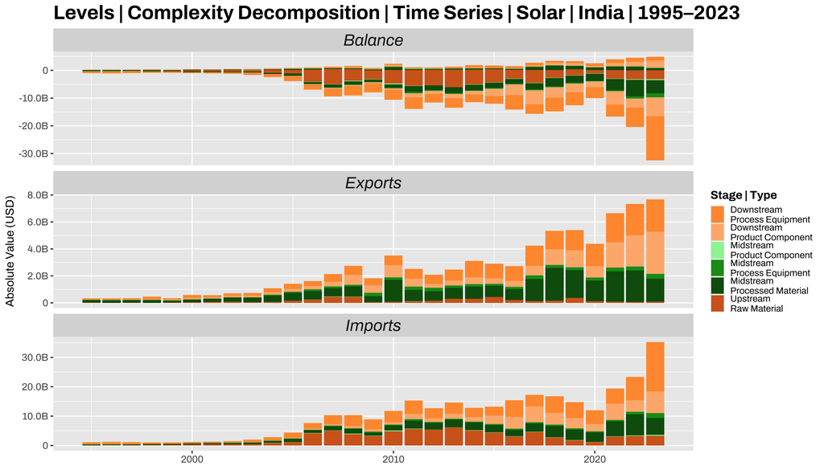

# 3 Scope

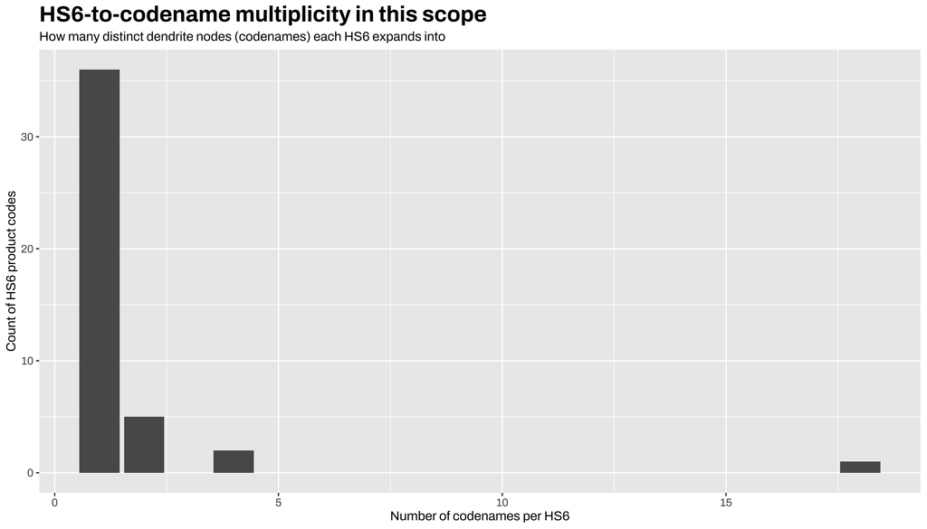

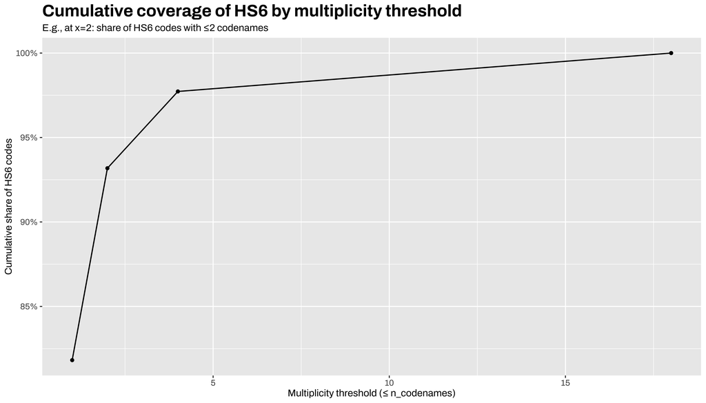

| product_code | n_codenames |
| --- | --- |
| 848620 | 18 |
| 847989 | 4 |
| 848610 | 4 |
| 260600 | 2 |
| 281820 | 2 |
| 700510 | 2 |
| 700719 | 2 |
| 851519 | 2 |
| 250510 | 1 |
| 251910 | 1 |
| 260300 | 1 |
| 260400 | 1 |
| 260900 | 1 |
| 261610 | 1 |
| 280450 | 1 |

# 4 HHI Concentration Risk

The **Herfindahl–Hirschman Index (HHI)** is a concentration measure computed as the sum of squared shares. It ranges from **0** (highly diversified) to **1** (fully concentrated in a single partner or product). In this context, HHI is not a “market power” claim but a **dependency signal**: high HHI means India’s imports (or its deficit exposure) are concentrated in a small set of partners or products, making the supply chain more fragile to shocks, sanctions, price spikes, or logistical disruptions.

We compute four HHI series over time:

1. Imports concentrated by **partner** (who India depends on).
2. Deficit exposure concentrated by **partner** (who controls the deficit).
3. Imports concentrated by **HS6 product** (what India depends on).
4. Deficit exposure concentrated by **HS6 product** (which items drive the deficit).

Interpreting the plot: rising HHI typically indicates **narrowing options** and potential leverage by a small set of suppliers. For upgrading strategy, a high and rising deficit-HHI suggests that capability-building (or diversification) should prioritize the few items/partners driving exposure.

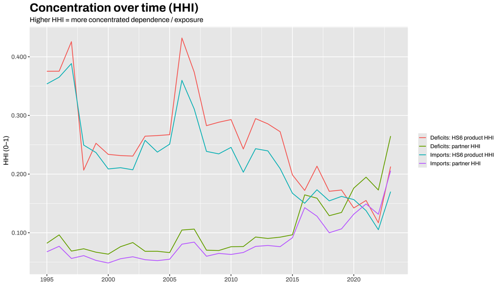

**Overall implication:** India’s green trade constraint has evolved from dependence on a few **technologies** toward layered dependence on a few **countries supplying those technologies**, while the core product-level deficits continue to anchor structural vulnerability.

# 5 Balances and Deficit Construction

Balances are computed as:

- **balance = exports − imports**
- **deficit = max(imports − exports, 0)**

We compute these both at HS6 level (for external linking) and at codename level (for dendrite-consistent diagnostics). The codename series is the one you want when you later relate trade performance to **distance-to-final** or to dendrite “critical paths”, because the node identity is aligned.

# 6 Deficit Persistence across Subperiods

Upgrading bottlenecks are rarely one-off: what matters is whether import dependence is **persistent** across long subperiods. A persistent deficit item is a candidate “structural gap”: it survives changing macro conditions, trade regimes, and industrial policy phases.

We split the sample into three windows:

- 1995–2005
- 2006–2014
- 2015–2023

and classify each codename (or HS6 code) as:

- **Persistent deficit (all 3)**,
- deficit in 2 periods,
- deficit in 1 period,
- or no deficit.

Interpretation: persistent-deficit nodes are your best first-pass list of *capability constraints*. They are not necessarily “hardest” technologically—but they are repeatedly *not produced competitively*, and they anchor a concrete agenda for investigation: technology requirements, firm capabilities, IPR constraints, standards, scale economies, and supplier ecosystems.

| class | n | share |
| --- | --- | --- |
| Deficit in 1 period | 7 | 0.0972222 |
| Deficit in 2 periods | 33 | 0.4583333 |
| No deficit | 2 | 0.0277778 |
| Persistent deficit (all 3) | 30 | 0.4166667 |

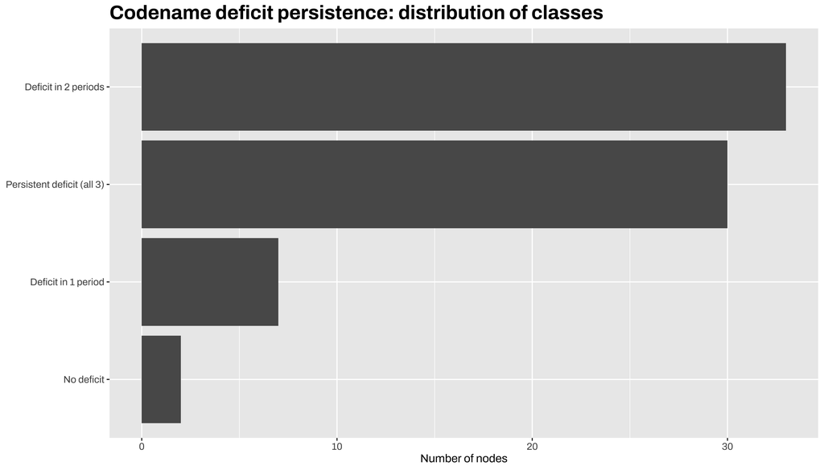

| class | n | share |
| --- | --- | --- |
| Deficit in 1 period | 5 | 0.1136364 |
| Deficit in 2 periods | 12 | 0.2727273 |
| No deficit | 2 | 0.0454545 |
| Persistent deficit (all 3) | 25 | 0.5681818 |

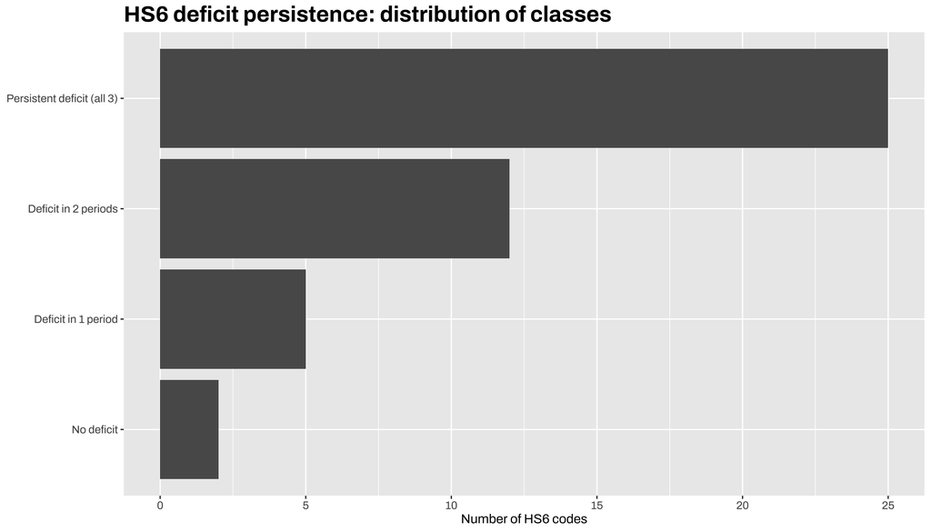

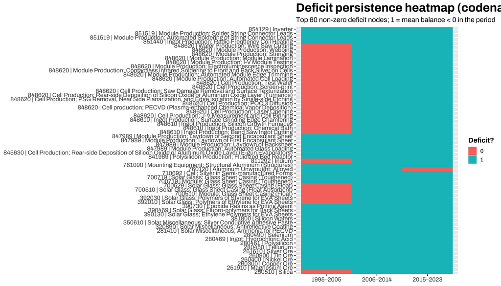

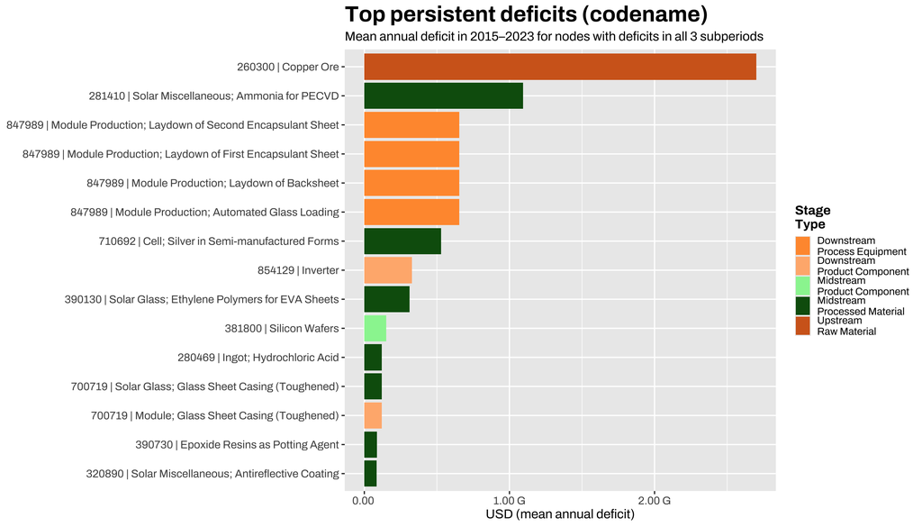

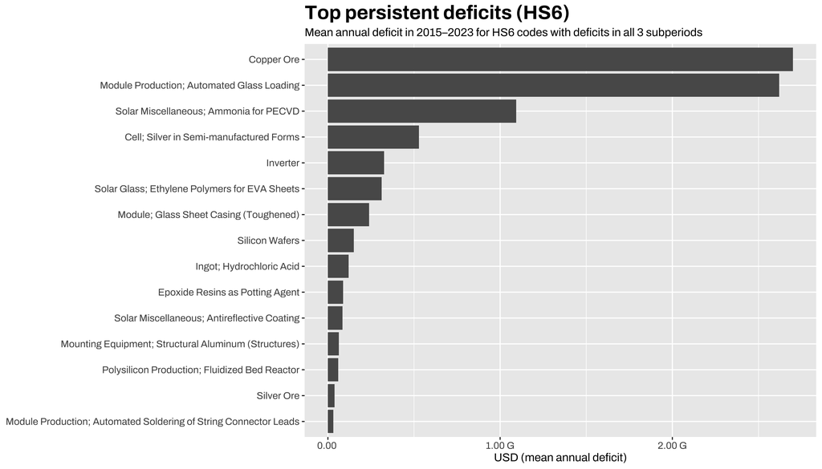

# 7 Widening Deficits by Stage×Type

A persistent deficit is important; a deficit that is **widening** is urgent. Here we aggregate to **stage×type** (codename-consistent) and compute the change in mean annual deficits between the early and late windows:

Δ deficit = mean(deficit) 2015–2023 minus mean(deficit) 1995–2005

Interpretation: the largest positive values identify where India’s import dependence is expanding faster than its export capacity in that segment. These are plausible candidates for:

- fast-growing domestic demand outpacing capability,
- increasing technological complexity (learning lag),
- or strategic choke points (supplier concentration, restricted tech).

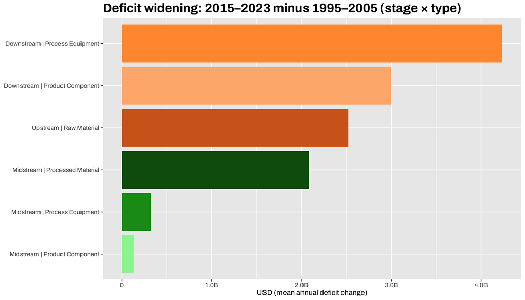

# 8 What this implies for Upgrading Strategy

Use the diagnostics as a triage system:

- **High deficit-HHI by product** + **persistent deficit items**: likely **hard bottlenecks**; investigate feasibility of domestic capability, substitution, or diversification.
- **Widening deficits in downstream process equipment**: suggests **capital goods / automation / precision** constraints that will shape the whole chain (equipment is often a “meta-bottleneck”).
- **Low concentration but persistent deficit**: suggests dependence is broad-based; the issue may be **systemic capability** (skills, standards, finance, scale) rather than a single supplier.
- **Low deficits near finals but high deficits upstream/midstream**: suggests India may be assembling/expanding deployment while remaining dependent on materials and equipment inputs.

This report should therefore feed directly into a short “industrial intelligence” checklist for the largest persistent/widening deficit nodes: what firms exist domestically, what is imported (and from whom), what standards constrain entry, where is learning happening, and what policy levers are realistic (public procurement, credit, joint ventures, licensing, local content, R&D, or trade agreements).

# 9 Benchmarking vs region and world

We compare India’s **imports composition by stage×type** to: - **Region average** (from `pc_data`, if available) - **World average** (all countries present in bilateral data for this tech)

This is designed for *structural comparison*, not causal claims.

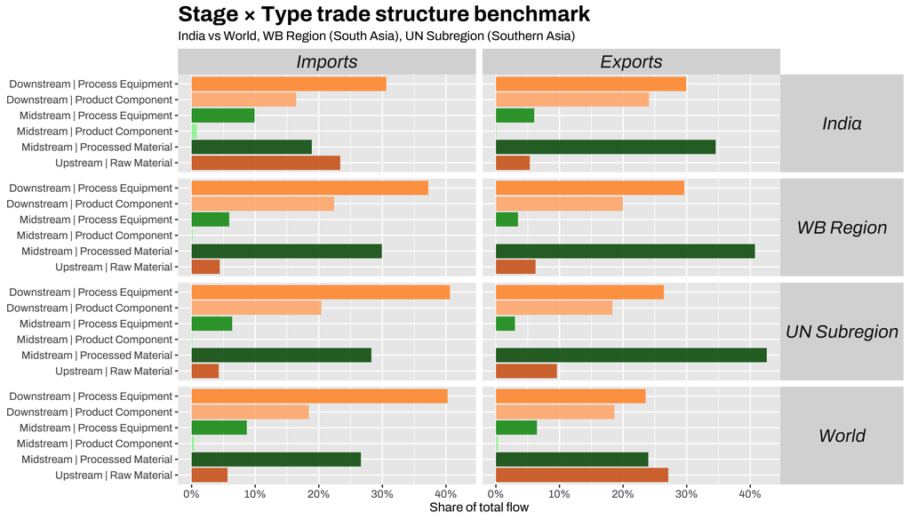

# 10 5. Within-country rankings of stage×type (best vs worst)

```
$best
# A tibble: 6 × 7
  type_stage             mean_exports mean_imports mean_balance mean_balance_fmt
  <chr>                         <dbl>        <dbl>        <dbl> <chr>
1 Midstream | Product C…     3081396.    86139236.   -83057839. -83.1M
2 Midstream | Process E…   143124931.   296217070.  -153092139. -153.1M
3 Midstream | Processed…   895034891.  1987206999. -1092172108. -1.1B
4 Downstream | Product …   613751216.  1717271314. -1103520098. -1.1B
5 Upstream | Raw Materi…   143019854.  2578565886. -2435546032. -2.4B
6 Downstream | Process …   802033821.  3330206407. -2528172586. -2.5B
# ℹ 2 more variables: mean_exports_fmt <chr>, mean_imports_fmt <chr>

$worst
# A tibble: 6 × 7
  type_stage             mean_exports mean_imports mean_balance mean_balance_fmt
  <chr>                         <dbl>        <dbl>        <dbl> <chr>
1 Downstream | Process …   802033821.  3330206407. -2528172586. -2.5B
2 Upstream | Raw Materi…   143019854.  2578565886. -2435546032. -2.4B
3 Downstream | Product …   613751216.  1717271314. -1103520098. -1.1B
4 Midstream | Processed…   895034891.  1987206999. -1092172108. -1.1B
5 Midstream | Process E…   143124931.   296217070.  -153092139. -153.1M
6 Midstream | Product C…     3081396.    86139236.   -83057839. -83.1M
# ℹ 2 more variables: mean_exports_fmt <chr>, mean_imports_fmt <chr>
```

# 11 6. Peer countries (similar import composition)

We define peers as countries with the most similar **stage×type import share vectors** (cosine similarity).

```
$peers_imports
# A tibble: 5 × 4
  iso3    sim country_name flow
  <chr> <dbl> <chr>        <chr>
1 LKA   0.867 Sri Lanka    Imports
2 BGD   0.836 Bangladesh   Imports
3 PAK   0.828 Pakistan     Imports
4 AFG   0.770 Afghanistan  Imports
5 NPL   0.730 Nepal        Imports

$peers_exports
# A tibble: 5 × 4
  iso3    sim country_name flow
  <chr> <dbl> <chr>        <chr>
1 NPL   0.937 Nepal        Exports
2 BGD   0.899 Bangladesh   Exports
3 AFG   0.835 Afghanistan  Exports
4 PAK   0.818 Pakistan     Exports
5 LKA   0.803 Sri Lanka    Exports
```

# 12 7. Distance to final product (from dendrite)

We compute shortest path distance in the dendrite graph to **final products**.

- If a node has `stage` containing “final”, it is a final node.
- Otherwise, finals are nodes with out-degree 0.

This replicates the logic in your dendrite submodule and yields `dist_to_final` for each `codename`.

| codename | dist_to_final |
| --- | --- |
| 830249 \| Mounting Equipment | 1 |
| 760120 \| Aluminum Unwrought; Alloyed | 2 |
| 281820 \| Alumina | 3 |
| 260600 \| Bauxite Ore | 4 |
| 854129 \| Inverter | 1 |
| 848620 \| Module Production; Electroluminescence Inspection | 1 |
| 848620 \| Module Production; I-V Module Testing | 2 |
| 851519 \| Module Production; Automated Soldering of String Connector Leads | 3 |
| 848620 \| Module Production; Automated Module Edge Trimming | 4 |
| 848620 \| Module Production; Module Lamination | 5 |

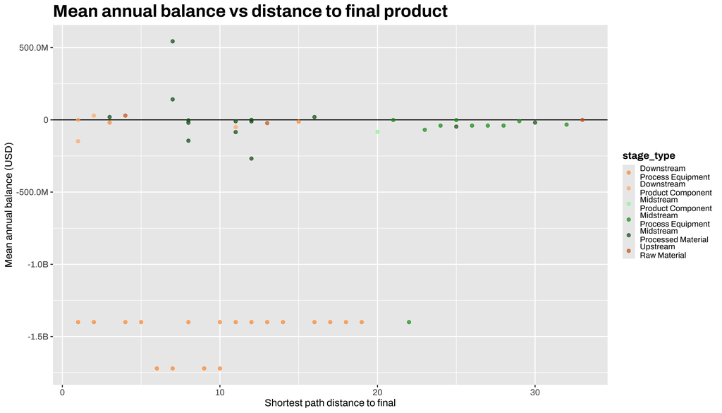

# 13 What to operationalize (interpretive checklist)

This report produces *signals*; you still need policy interpretation.

- **High HHI deficit exposure** → concentrated vulnerability: target supplier diversification or domestic substitution.
- **Persistent deficit products** → structural gaps: likely the binding constraints for upgrading.
- **Widening deficits** → urgency: where capability acquisition must keep up with demand.
- **Benchmark gaps** → atypical positioning: implies either niche specialization or missing segments.
- **Deficit vs distance-to-final** → whether gaps cluster near final assembly vs earlier stages.